# Análise das viagens de taxi em Nova York

Rafael

August 02, 2018

## Introdução

Antes de entrar um pouco nos insights que podem ser extraídos através do banco de dados é imporante detalhar um pouco o processo de criação do mesmo.

1. O primeiro passo foi realizar uma exploração dos dados simples identificar potenciais problemas que poderiam ocorrer durante o processo de inserção dos dados em um banco de dados. Além de ser uma etapa muito importante para definição dos tipos de dados que serão utilizados.

Ainda nessa etapa, foi realizada uma prototipação das consultas que seriam utilizadas para obter os dados solicitados do banco de dados. Essa etapa foi feita em uma amostra do banco de dados com 100.000 linhas (aleatóriamente selecionadas) para permitir uma comparação entre os resultados obtidos por meio de uma consulta no banco de dados e os resultados obtidos utilizando a biblioteca `pandas`

2. Automação do processo de ETL através da utilização de scripts de python e um script do bash (Shell):
- create_tables.py
- etl.py
- sql_queries.py
- cloud_config.py
- automate_elt.sh

Para tanto, houve a criação de um script que através da obtenção de dois inputs do usuário: `AWS_ACCESS_KEY_ID` e `AWS_SECRET_ACCESS_KEY` permite automatizar todo o processo de criação de um cluster na Nuvem especificamente para esse projeto.

## Quesitos Mínimos

### Distância média percorrida em viagens com no máximo dois passageiros

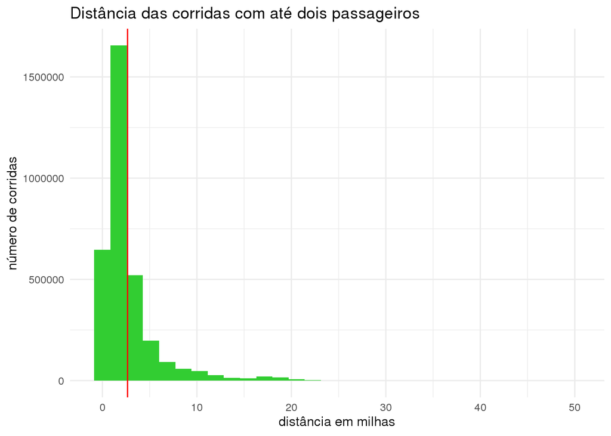

### Quantidade total arrecada pelas três maiores empresas de taxi de Nova York

```python
cur.execute("""
SELECT nome, current, SUM(total_amount), COUNT(*)
FROM trips t
JOIN vendors v
ON t.vendor_id = v.vendor_id
WHERE total_amount IS NOT NULL
GROUP BY 1, 2
ORDER BY 3 DESC

""")
results = cur.fetchall()

# checando se o retorno possui o mesmo número de linhas que a tabela na cloud
assert sum([i[3] for i in results]) == 4000000

quantidade_arrecadada = [{'vendor': i[0], 'valor_total': i[2], 'numero_de_corridas': i[3]} for i in results]
quantidade_arrecadada = pd.DataFrame(quantidade_arrecadada)
```

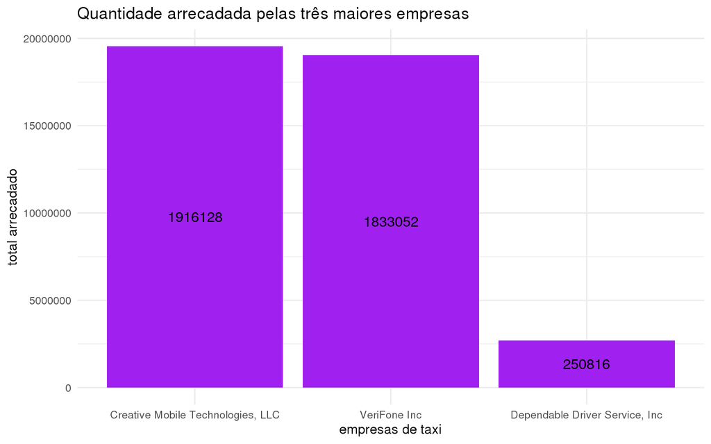

```r
quantidade_arrecadada <- as.data.frame(py$quantidade_arrecadada)

quantidade_arrecadada %>%
  # removendo a empresa que só possui uma corrida
  filter(valor_total > 100000) %>%

  # criando o gráfico
  ggplot(aes(reorder(vendor, -valor_total), valor_total, label=numero_de_corridas)) +
  geom_bar(stat='identity', fill='purple') +
  scale_fill_gradientn(colours = c('blue','green')) +
  geom_text(size=4, position = position_stack(vjust=0.5)) +
  labs(title='Quantidade arrecadada pelas três maiores empresas',
       x='empresas de taxi',
       y='total arrecadado')
```

```r
quantidade_arrecadada
```

```
##   numero_de_corridas valor_total                            vendor
## 1            1916128  19549084.3 Creative Mobile Technologies, LLC
## 2            1833052  19043434.0                      VeriFone Inc
## 3             250816   2714901.7    Dependable Driver Service, Inc
## 4                  4        45.6                Total Solutions Co
```

### Distribuição mensal das corridas pagas em dinheiro nos últimos quatro anos

```python
cur.execute("""
SELECT EXTRACT(year FROM pickup_datetime) AS year,
    EXTRACT(month FROM pickup_datetime) AS month,
      COUNT(*)
FROM trips
GROUP BY 1, 2
""")
results = cur.fetchall()


# transformando os dados obtidos em um dataframe com o index igual a data.
distribuição_all = [{'data_mês': datetime.strptime(str(i[0]) + '-' + str(i[1]), '%Y-%m'),
                 'numero_de_corridas': i[2]} for i in results]
distribuição_all = pd.DataFrame(distribuição_all)
```

```r
distribuição <- as.data.frame(py$distribuição)
distribuição_all <- as.data.frame(py$distribuição_all)


plot1 <- distribuição %>%
  ggplot(aes(data_mês, numero_de_corridas)) + geom_line() +
  labs(title='Distribuição das corridas pagas em dinheiro por mês (2009-2012)',
       x='mês e ano', y='número de corridas')

plot2 <- distribuição_all %>%
  ggplot(aes(data_mês, numero_de_corridas)) + geom_line() +
  labs(title='Distribuição das corridas por mês (2009-2012)',
       x='mês e ano', y='número de corridas')
```